# Minerals Identification and Classification

Dr. Ahmad Redaa

2024-09-24

# Mineral identification

## Mineral Diversity

- There are over **5530 minerals** known in nature, and new minerals are discovered every year.
- Each mineral has a **unique chemical composition**, but many minerals appear similar in shape or form.

## Challenges in Mineral Study

- With so many minerals, studying them individually is a difficult task.
- Some minerals have **similar crystal forms** and can appear nearly identical to others.
- Advanced techniques to identify minerals: such as Electron Microprobe and X-ray Diffraction.

# Mineral Classification

- **Minerals** consist of cations (positively charged ions) and anions (negatively charged ions) or anion complexes.
- Example: Hematite (Fe₂O₃)
  - Cation: Fe³⁺ (Iron)
  - Anion: O²⁻ (Oxygen)
- This classification was originally proposed by American geologist James Dwight Dana.
- it’s known as Dana System

# Mineral Groups

- Minerals are classified based on their **predominant anion** or anion complex.
- **Main Groups**:
  - Native Minerals
  - Oxides
  - Silicates
  - Carbonates
  - Sulphides
  - Sulphates
  - Halides
  - Phosphates

# Oxides and Sulphides

## Oxides

- Contain oxygen (O²⁻) as their anion.
- **Examples**:
  - Hematite (Fe₂O₃)
  - Corundum (Al₂O₃)

## Sulphides

- Contain sulphur (S²⁻) as their anion.
- **Examples**:
  - Galena (PbS)
  - Pyrite (FeS₂)

# Sulphates, Halides, and Carbonates

## Sulphates

- Contain SO₄²⁻ anions.
- **Examples**: Gypsum (CaSO₄ · 2H₂O), Barite (BaSO₄)

## Halides

- Contain halogen elements (Cl⁻, F⁻, etc.).
- **Examples**: Halite (NaCl), Fluorite (CaF₂)

### Carbonates

- Contain CO₃²⁻ anions.
- **Examples**: Calcite (CaCO₃), Dolomite ((Ca,Mg)CO₃)

# Phosphates and Native Minerals

## Phosphates

- Contain PO₄³⁻ anions.
- **Examples**: Apatite (Ca₅(PO₄)₃(OH))

## Native Minerals

- Single-element minerals.
- **Examples**: Gold (Au), Graphite (C), Sulfur (S)

# Silicates Mineral Groups

## Main Silicate Groups

- **Isolated Tetrahedra** (e.g., Olivine)
- **Single Chains** (e.g., Pyroxene)
- **Double Chains** (e.g., Amphibole)
- **Sheet Silicates** (e.g., Mica)
- **Framework Silicates** (e.g., Quartz, Feldspar)

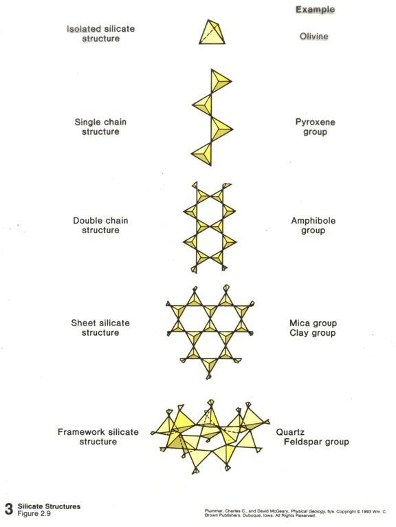

Source: [https://www.quora.com](https://www.quora.com/What-is-the-definition-of-silicate-minerals)

# Mineral Group Summary

### Mineral Groups Overview

- **Oxides**: Hematite, Corundum
- **Sulphides**: Galena, Pyrite
- **Sulphates**: Gypsum, Barite
- **Halides**: Halite, Fluorite
- **Carbonates**: Calcite, Dolomite
- **Phosphates**: Apatite
- **Native Minerals**: Gold, Graphite
- **Silicates**: Quartz, Feldspar